# STAT 240

Week 9: Clustering and Strings

Owen G. Ward

## Today

- Recap on classification and CV
- An introduction to clustering
- Manipulating Text Data: Strings

# Recap: Classification

## Predicting Categories

- We had numeric data $X$ and we wanted to use it to predict a categorical variable $Y$
- Need different models to those for predicting numeric $Y$
- Need a different way to evaluate these models (RMSPE doesn’t make sense)

## What this looks like

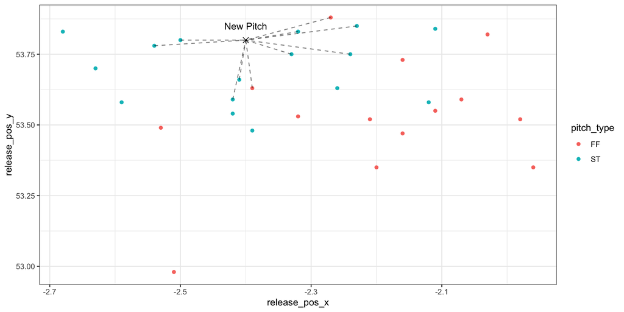

## KNN for Classification

- Find the nearest points in the training set to the $X$ we want to predict at
- See which class occurs the most often in those nearby points
- This is our prediction for a new point at $X$

## Finding Nearest Neighbours

- Use Euclidean distance to determine which points are nearest
- Can compute this using

$$\text{distance} = \sqrt{(x - x_{new})^2 + (y - y_{new})^2}$$

## Evaluating Predictions

- Need something that can measure the difference between predictions of categories

$$\text{accuracy} = \frac{\text{how many correct predictions}}{\text{how many data points we predict at}}$$

- Can either predict the correct category or get it wrong, no other possibilities

## Choosing K - Cross Validation

- To choose the optimal $K$ in KNN we can only use the training data
- Not allowed access to the test set, otherwise would overfit
- Solve this using **Cross Validation**

## The full process

```r
library(class)
K_vals <- seq(from = 1, to = 200, by = 1)
K_acc <- rep(NA, length(K_vals))
set.seed(100)

CV_folds <- sample(1:5, size = nrow(training_data), replace = TRUE)
num_folds <- 5

for(j in 1:length(K_vals)) {
  k <- K_vals[j]
  CV_acc <- rep(NA, num_folds)

  for(i in 1:num_folds){
    cv_train <- training_data[CV_folds != i, ]
    cv_val <- training_data[CV_folds == i, ]
    fit_knn <- knn(train = as.matrix(cbind(cv_train$release_pos_x,
                                   cv_train$release_pos_y)),
           test = as.matrix(cbind(cv_val$release_pos_x,
                                  cv_val$release_pos_y)),
           cl = cv_train$pitch_type, k = k)
    CV_acc[i] <- mean(fit_knn == cv_val$pitch_type)
  }
  K_acc[j] <- mean(CV_acc)
}
```

# Clustering

## What is Clustering?

- Group similar data items together
- Exploratory data analysis / pattern recognition
- Example of *unsupervised learning* (a branch of ML)

## Unsupervised Learning

- A different data science approach to regression/classification
- No variable $Y$ we are trying to predict
- Instead just want to identify similar types of data
  - Similar customers on some shopping website, etc
- Important data science tool for understanding the data, structure of the data

## Unsupervised Learning

- No $Y$ we are trying to predict!
- No way to “predict” or “evaluate” these methods, but give you information about the data
- Often use these alongside tools for prediction, for slightly different datasets

## Simulated data

- Used [Calm Code](https://calmcode.io/labs/drawdata.html) to simulate a dataset demonstrating clustering

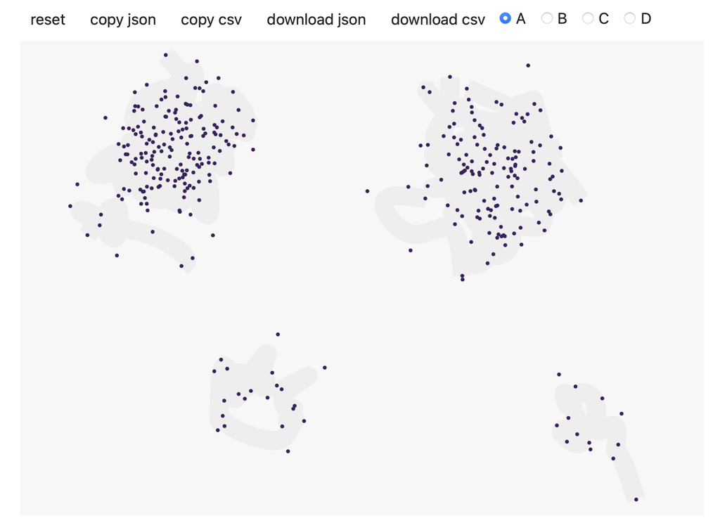

## Simulated data

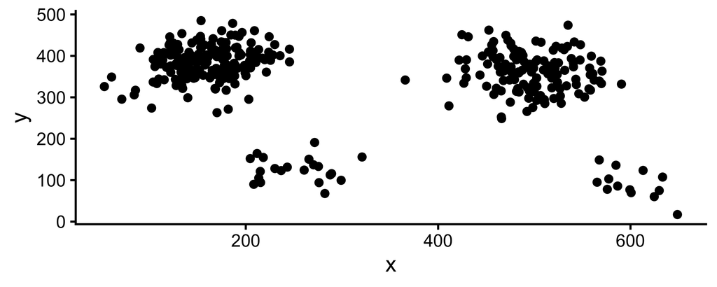

```r
data <- read.csv("data.csv")
library(ggplot2)
ggplot(data, aes(x = x, y = y)) +
  theme_classic() +
  geom_point()
```

## k-means clustering

The simplest clustering method is k-means clustering

- Iterative method with random initialization
- The parameter is fixed: the number of clusters *k*
- Somewhat different to KNN!
  - There are ways to choose $k$ but not using CV (no predictions)
  - Come back to this in a few minutes

## k-means clustering in 2D

- Step 1: Randomly assign each data item to one of the *k* clusters

```r
N <- dim(data)[1]
K <- 4
set.seed(240)
cluster <- sample(K, size = N, replace = TRUE)
data$cluster <- cluster
p <- ggplot(data, aes(x = x, y = y, color = as.factor(cluster))) +
  labs(color = "cluster") +
  theme_classic() +
  geom_point()
print(p)
```

## Random Clusters

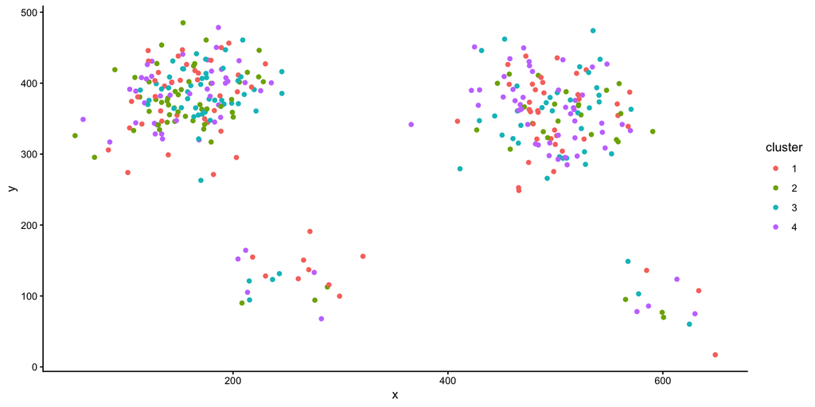

- Step 2: Compute the mean *x* and *y* coordinate of each cluster (this is called a centroid)
- If a cluster is empty, assign the corresponding centroid to a randomly selected data item

```r
mus <- matrix(NA, K, 3)
colnames(mus) <- c("x", "y", "cluster")
for (k in 1:K) {
  mus[k, 1] <- mean(data$x[data$cluster == k])
  mus[k, 2] <- mean(data$y[data$cluster == k])
  mus[k, 3] <- k
}
q <- p + geom_point(as.data.frame(mus),
                    mapping = aes(x = x, y = y,
                                  color = as.factor(cluster)),
                    shape = 4, stroke = 1) +
  theme(legend.position = "none")
print(q)
```

## k-means clustering in 2D

- Step 2:

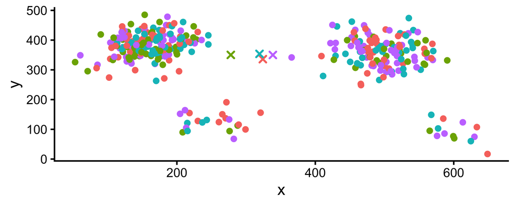

## k-means clustering in 2D

- Step 3: Reassign each data item to the cluster with the closest centroid

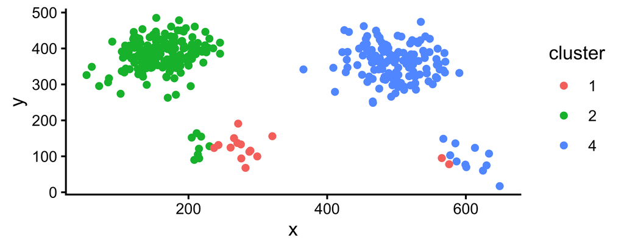

## Notes

- This only uses 3 clusters here, but still have a 4th cluster
- If a cluster is empty, assign the corresponding centroid to a randomly selected data item
- So will randomly take one of these points and make that cluster 3 before the next step

## k-means clustering in 2D

- Iterate by repeating steps 2 and 3 until a stopping condition is met
- Examples of stopping conditions:
1. A maximum number of iterations is reached
2. The cluster assignment doesn’t change
3. The centroids move by only a small amount
- Stop the first time one of these happens

## k-means clustering in 2D

- The result may look something like this:

```r
set.seed(240)
result <- kmeans(data[, 1:2], 4, iter.max = 100)
data$cluster <- result$cluster
p <- ggplot(data, aes(x = x, y = y, color = as.factor(cluster))) +
  labs(color = "cluster") +
  theme_classic() +
  geom_point()
print(p)
```

## Final Clusters

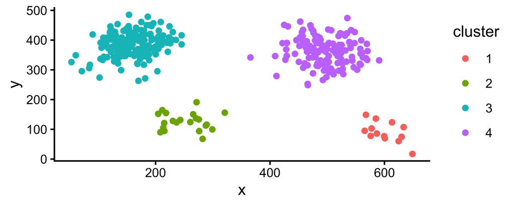

## The clusters

- The points in a cluster are more similar to each other than observations in a different group
- That’s the underlying quantity clustering is capturing in the data, which is pretty vague!
- Won’t get into the math behind this, will see it in other classes

## k-means theory

- The k-means algorithm is one of the simplest clustering algorithms
- A big drawback is that you have to already know how many clusters you want
- Another drawback is that the “variance” of each cluster is the same: A cluster that is very compact might have a k-means solution that includes aspects of other clusters

## k-means theory

- Another drawback is that k-means clustering doesn’t work for “non convex” clusters
- No clear rules for how to implement this, involves quite a bit of trial and error!

## k-means can get stuck

- When you run `kmeans` you randomly put each point in one of the k clusters
- How you do this can impact the clustering you get
- To get around this:
  - Start from multiple different random clusters (`nstart` in R)
  - Choose the one which gives the best separated clusters

## Implementing this in R

- Use the `kmeans` function, don’t need any packages
- Need the data to all be numeric
- Specify $k$ and how many iterations to run (stopping rule)

```r
result <- kmeans(data[, 1:2], 4, iter.max = 100)
head(result$cluster) ## cluster each point is in
```

```
[1] 4 4 4 4 1 1
```

- More random starts could give different clusters

```r
result2 <- kmeans(data[, 1:2], 4, iter.max = 100, nstart = 10)
head(result2$cluster)
```

```
[1] 1 1 1 1 1 1
```

- The numbers can change from run to run, same numbers in one fit mean the same cluster

## Choosing K

- For different values of $K$, compute the variance of points withing the clusters
- Plot these, choose the value of $K$ where this stops decreasing

```r
K_vals <- 1:10
wss <- rep(NA, length(K_vals))

for (i in seq_along(K_vals)) {
  result <- kmeans(data[, 1:2], centers = K_vals[i], iter.max = 100, nstart = 10)
  wss[i] <- result$tot.withinss
}
```

## Plotting this

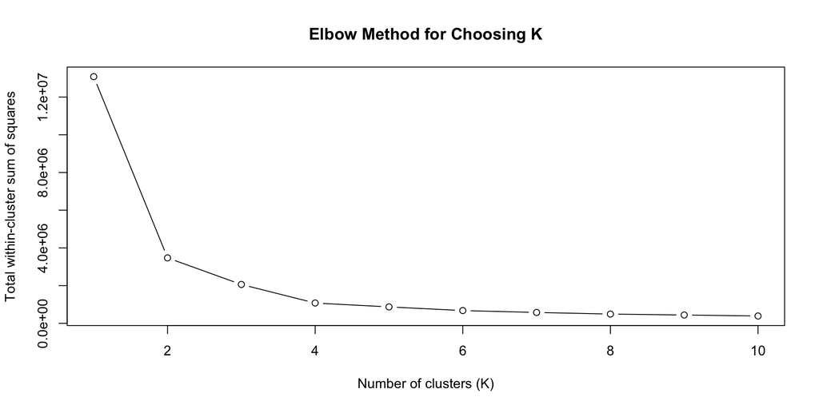

- Find the “elbow”, where this quantity stops decreasing, maybe $K=3/4$ here, not very exact!

## Exercise

- Suppose we have the dataset `peng_scaled` with 2 variables and we have the positions of 3 centroids, `centroids`. Write an R function `my_dist` which will compute the distance between these centroids and all points in the dataset. If you have $n$ rows in your data and $K$ centroids, this will be an $n\times K$ matrix, where the entries in the first row will be the distance from that point to each centroid, respectively.
- To create a matrix `dist_mat <- matrix(NA, nrow = ..., ncol = ...)`

```r
peng_scaled <- read.csv("peng_scaled.csv")
```

```r
set.seed(100)
head(peng_scaled)
```

```
# A tibble: 6 × 2
  flipper_scaled bill_scaled
           <dbl>       <dbl>
1         -1.42       -0.883
2         -1.06       -0.810
3         -0.421      -0.663
4         -0.563      -1.32
5         -0.776      -0.847
6         -1.42       -0.920
```

```r
centroids <- sample_n(peng_scaled, size = 3)
centroids
```

```
# A tibble: 3 × 2
  flipper_scaled bill_scaled
           <dbl>       <dbl>
1          0.646       0.491
2         -0.563      -0.773
3          1.14        0.472
```

# Text Data: Strings

## String manipulation

String manipulation for text data comes up all the time!

- Natural language processing (NLP)
  - Sentiment analysis
  - Chatbots, translation
  - Electronic healthcare records …
- Preprocessing data sources
  - Normalization of factors
  - Parsing websites or documents …
- Data analysis
  - Understanding DNA …

## String manipulation

- We’ll review string manipulation in base R.
- First, we will read the text of the Great Gatsby (Fitzgerald 1925) into a single string variable

```r
fn <- "gatsby.txt"
s <- readChar(fn, file.info(fn)$size)
nchar(s) # Print number of characters in text
```

```
[1] 296673
```

```r
length(s)
```

```
[1] 1
```

- This reads the whole text into a single character string

## Why we need to manipulate this

```r
substring(s, 3504, 3775)
```

```
[1] " If personality is an unbroken series of\r\nsuccessful gestures, then there was something gorgeous about him, some\r\nheightened sensitivity to the promises of life, as if he were related\r\nto one of those intricate machines that register earthquakes ten\r\nthousand miles away. "
```

- This is not just the text, other characters that we need to deal with
- Probably don’t care about punctuation also

## String manipulation

- We want a character vector with one word per element

```r
x <- strsplit(s, "\\s+")
length(x)
```

```
[1] 1
```

- Here, `"\\s+"` is telling R to split based on **whitespace** in the character string
- This is what’s known as a **regular expression**, way to detect common patterns in text
- Will come back to these in more detail next week
- Places this output in a list of length 1

```r
x <- unlist(x)
print(x[507:517])
```

```
 [1] "I"       "felt"    "that"    "I"       "wanted"  "the"     "world"
 [8] "to"      "be"      "in"      "uniform"
```

- Here because we only have one element in our list, can just use `unlist` to basically unnest this into a vector

```r
length(x)
```

```
[1] 51257
```

## Wordclouds

- We can create a wordcloud of the document (visualization, not much use for actual data science)

```r
library(wordcloud)
word_counts <- table(x)
wordcloud(names(word_counts), word_counts) ## this is very slow
```

- `word_counts` will store how many times each word occurs in the document

```r
word_counts[101:107]
```

```
x
   “crazy    “Crazy “creative    “Daisy   “Daisy,   “Daisy!  “Daisy?”
        1         2         1         1         1         1         1
```

- You may want to process these a bit more!

## A strange wordcloud

[figure not shown]

## Wordclouds

- In NLP, we often ignore “stopwords” such as “a” and “the”. Here, we also ignore infrequent words

```r
library(stopwords)
stopwords("en")[1:10]
```

```
 [1] "i"         "me"        "my"        "myself"    "we"        "our"
 [7] "ours"      "ourselves" "you"       "your"
```

```r
x <- tolower(x) ## so Crazy and crazy the same
x <- x[!(x %in% stopwords("en"))]
word_counts <- table(x)
word_counts <- word_counts[word_counts >= 20] ## remove rare words
word_counts[101:110]
```

```
x
  know   last   left    let  light   like little   long   look looked
    70     41     37     25     25    116     91     55     34     82
```

## A better wordcloud

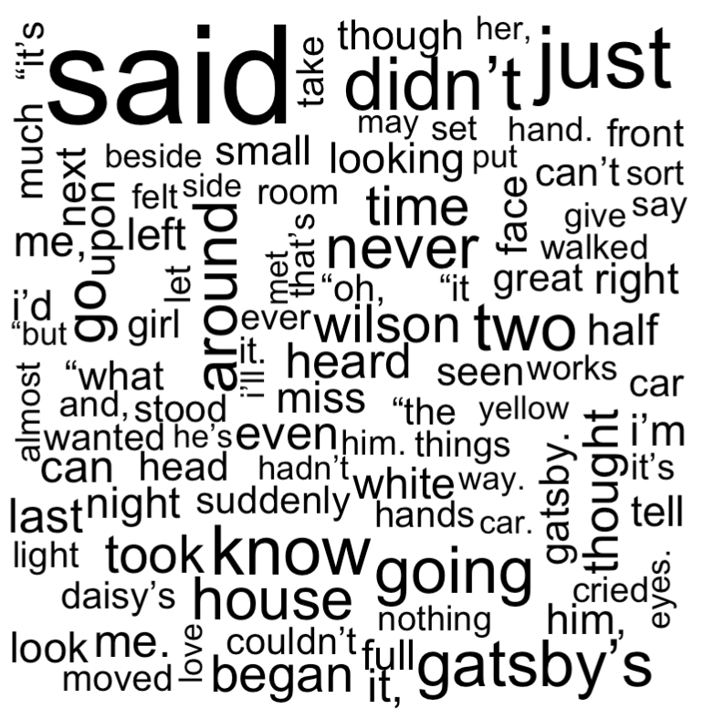

## Low level string manipulation

Easiest R package: `stringr`

- Match a string and extract it `str_extract`
- Detect a matching string `str_detect`
- Replace one string with another `str_replace`
- Split a string on a substring `str_split`
- Many other options possible!

## Strings: extracting

```r
library(stringr)
a <- c("apples x4", "bag of flour", "bag of sugar", "milk x2")
str_extract(a, "\\d") ## looking for digits
```

```
[1] "4" NA  NA  "2"
```

```r
str_extract(a, "[a-z]+") ## anything starting with one or more letters
```

```
[1] "apples" "bag"    "bag"    "milk"
```

```r
str_extract_all(a, "[a-z]+") ## anything starting with one or more letters
```

```
[[1]]
[1] "apples" "x"

[[2]]
[1] "bag"   "of"    "flour"

[[3]]
[1] "bag"   "of"    "sugar"

[[4]]
[1] "milk" "x"
```

## Strings: detecting

```r
a <- c("apple", "banana", "pear", "pineapple")
str_detect(a, "a")
```

```
[1] TRUE TRUE TRUE TRUE
```

```r
str_detect(a, "^a") ## starts with a
```

```
[1]  TRUE FALSE FALSE FALSE
```

```r
str_detect(a, "apple")
```

```
[1]  TRUE FALSE FALSE  TRUE
```

```r
str_detect(a, "e$") ## ends in e
```

```
[1]  TRUE FALSE FALSE  TRUE
```

## Strings: replacing

```r
a <- c("one apple", "two pears", "three bananas")
str_replace(a, "[aeiou]", "-")
```

```
[1] "-ne apple"     "tw- pears"     "thr-e bananas"
```

```r
str_replace_all(a, "[aeiou]", "-")
```

```
[1] "-n- -ppl-"     "tw- p--rs"     "thr-- b-n-n-s"
```

## Strings: splitting

```r
a <- c(
  "apples and oranges and pears and bananas",
  "pineapples and mangos and guavas"
)
str_split(a, " and ")
```

```
[[1]]
[1] "apples"  "oranges" "pears"   "bananas"

[[2]]
[1] "pineapples" "mangos"     "guavas"
```

```r
str_split(a, "\\s+")
```

```
[[1]]
[1] "apples"  "and"     "oranges" "and"     "pears"   "and"     "bananas"

[[2]]
[1] "pineapples" "and"        "mangos"     "and"        "guavas"
```

## Exercise

- The following code gives you the text of the Austen novel Emma, with each line in a separate character vector.

```r
library(janeaustenr)
data("emma")
emma[1:4]
```

```
[1] "EMMA"           ""               "By Jane Austen" ""
```

```r
emma[106:108]
```

```
[1] "reconciled to his own daughter's marrying, nor could ever speak of her"
[2] "but with compassion, though it had been entirely a match of affection,"
[3] "when he was now obliged to part with Miss Taylor too; and from his"
```

- What proportion of these lines contain the word `Emma`? What about another more minor character, `Jane`?

## More details

- What if we wanted to find how many times the name `Emma` used?
- Will this give us the correct answer?

## Sentiment Analysis

- Sentiment analysis a way to determine how positive/negative text is, how this changes over time
  - Number of positive words - number of negative words
- Interesting way to analyse text
- Anyone read any Jane Austen novels?
- See [the Tidy Text Mining book](https://www.tidytextmining.com/) for more interesting applications

## Sentiments in Austen Novels

[figure not shown]